# PoolPoweR: Designing pool-tested surveys for detection or estimation of prevalence

2023-06-27

# Pooled (AKA Group) Testing

- Pooled testing:

  Any time you test groups of items instead of individuals
- Why?

  It might be cheaper, faster, or easier than individual testing *if prevalence is low*
- Why not?

  It complicates data analysis!

# Pooled Testing Example: Molecular Xenomonitoring

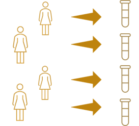

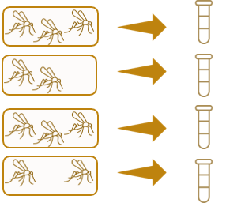

# Pooled Testing Example: Molecular Xenomonitoring

[figure not shown]

# Pooled Testing

Pooled testing can mean many things, but I am interested in:

- Binary outcome
- Tests are applied to groups of non-overlapping individuals
- Number of individuals in a pool (aka pool size) is known
- Interest is the presence/absence or prevalence of positive outcomes
- It is not possible to determine which or how many individuals in a positive group are positive

# Pooled Testing

Possible complications:

- Test might be imperfectly sensitive or specific
- Pool sizes might be different (or even random)
- Sampling design: simple random or cluster random

# Pooled Testing

Related but different:

- Pooled tests with a quantitative outcome (e.g. sewerage testing, qPCR)
- Pools where the number of individuals in each pool is unknown (e.g. sewerage testing)
- Where individuals from positive pools are re-tested (Dorfman screening or similar)

# Pool Testing Complicates Everything

- Estimation of prevalence:
  - Proportion of positive pools $>>$ prevalence
  - Maximum Liklihood Estimate (MLE) is better but is only asymptotically unbiased
  - PoolTestR only pacakge that allows prevalence estimate that accounts for clustering
- Open questions:
  - Sample size for prevalence estimation?
  - Optimal pool size?
  - Equal or unequal pools?
  - For cluster surveys, number of units per cluster?
  - What if samples per location is random?

> How much information do different sampling/pooling designs give you?

# Fisher Information

$$\begin{align}
I(\theta) & = E\left[\left(\frac{\partial}{\partial \theta}
\log(L(\theta|X))\right)^2\right] \\
& = E\left[\left(l_\theta(\theta|X)\right)^2\right] \\
& = -E\left[l_{\theta\theta}(\theta|X)\right] \\
\end{align}$$

# Fisher Information: Handy Properties

- Additive for independent data:
  $$\
  I_{X_1, X_2}(\theta) = I_{X_1}(\theta) + I_{X_2}(\theta)$$
- Maximum likelihood estimator with lots of data $X_1,\dots X_n$:
  $$\hat{\theta}_n \to Normal\left(\theta, \frac{1}{nI(\theta)}\right)$$

# Fisher Information: multiple parameters

$$\begin{align}
I(\theta, \rho)
&=
E \begin{bmatrix}
l_\theta(\theta, \rho|X) ^2 &
l_\theta(\theta, \rho|X) l_\rho(\theta, \rho|X)\\
l_\theta(\theta, \rho|X) l_\rho(\theta, \rho|X) &
l_\rho(\theta, \rho|X) ^2\\
\end{bmatrix}\\
& = -E \begin{bmatrix}
l_{\theta\theta}(\theta, \rho|X) &
l_{\theta\rho}(\theta, \rho|X)\\
l_{\rho\theta}(\theta, \rho|X) &
l_{\rho\rho}(\theta, \rho|X)\\
\end{bmatrix}\\
\end{align}$$
- Maximum likelihood estimator with lots of data $X_1,\dots X_n$:
$$\begin{bmatrix}
\hat{\theta}_n\\
\hat{\rho}_n\\
\end{bmatrix}
\to MN\left(
\begin{bmatrix}
\theta \\
\rho \\
\end{bmatrix}, \frac{I(\theta,\rho)^{-1}}{n}\right)$$

# Simple random surveys - single pool size

- Setup:
  - $s$ common pool size
  - $N$ number of pools
  - $Y$ the number of positive results
- Likelihood (perfect test)
  $$\begin{align}
  L(\theta|y)
  &= P(Y = y|\theta,N,s) \\
  &= {N \choose y} {(1 - (1-\theta)^{s})}^{y} (1-\theta)^{s(N-y)}
  \end{align}$$
- Fisher information
  $$\begin{align}
  I(\theta|N,s)
  = N\frac{s^2(1-\theta)^{s-2}}{1 - (1-\theta)^s}\\
  \end{align}$$

# Simple random surveys - many pool sizes

- Setup:
  - $\underline{s} = [s_1,\dots,s_K]$ vector of pool sizes
  - $\underline{N} = [N_1, \dots, N_K]$ number of pools of each size
  - $\underline{s}\cdot\underline{N} = n$ total number of units
  - $\underline{Y} = [Y_1,\dots, Y_K]$ the number of positive pools
- Likelihood
  $$\begin{align}
  L(\theta|\underline{y}) = \prod_{k = 1} ^K {N_k \choose y_k} {(1 -
  (1-\theta)^{s_k})}^{y_k} (1-\theta)^{s_k(N_k-y_k)}
  \end{align}$$
- Fisher information
  $$\begin{align}
  I(\theta|\underline{N},\underline{s})
  = \sum_{k = 1}^K I(\theta|N_k,s_k) = \sum_{k = 1}^K
  N_k\frac{s_k^2(1-\theta)^{s_k-2}}{1 - (1-\theta)^{s_k}}\\
  \end{align}$$

# Simple random surveys - many pool sizes and imperfect test

Setup:

- $\underline{s} = [s_1,\dots,s_K]$ vector of pool/group sizes
- $\underline{N} = [N_1, \dots, N_K]$ number of pools/groups
- $\underline{s}\cdot\underline{N} = n$
- $\underline{Y} = [Y_1,\dots, Y_K]$ the number of positive results
- $\psi$ the specificity of the test
- $\varphi$ the sensitivity of the test
- $\phi_s(\theta) = (1-\psi)(1-\theta)^s + \varphi (1 - (1-\theta)^s)$ the probability a pool tests positive (given $s$ and $\theta$).
- Likelihood
  $$L(\theta|\underline{y}) = P(\underline{Y} =
  \underline{y}|\theta,\underline{N},\underline{s},\varphi,\psi) =
  \prod_{k = 1} ^K {N_k \choose y_k} {\phi_{s_k}(\theta)}^{y_k}
  (1-\phi_{s_k}(\theta))^{N_k-y_k}$$
- Fisher information
  $$\begin{align*}
  I(\theta|\underline{N}, \underline{s},\varphi,\psi)
  &= (1-\varphi-\psi)^2\sum_{k = 1}^K N_k
  \frac{s_k^2(1-\theta)^{2s_k-2}}{\phi_{s_k}(\theta)(1-\phi_{s_k}(\theta))}\\
  \end{align*}$$

# Design Effect - Comparing information between designs

# Design Effect

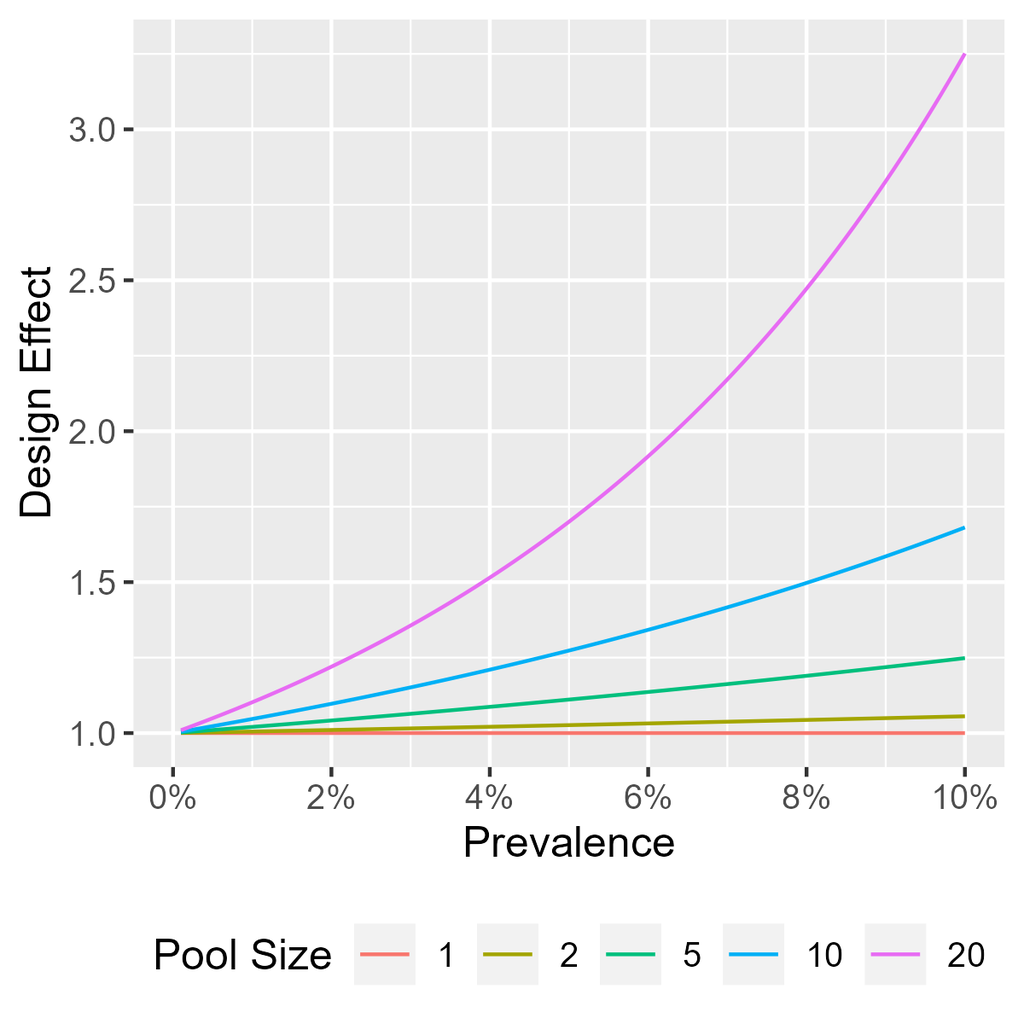

# Design Effect - Imperfect Specificity

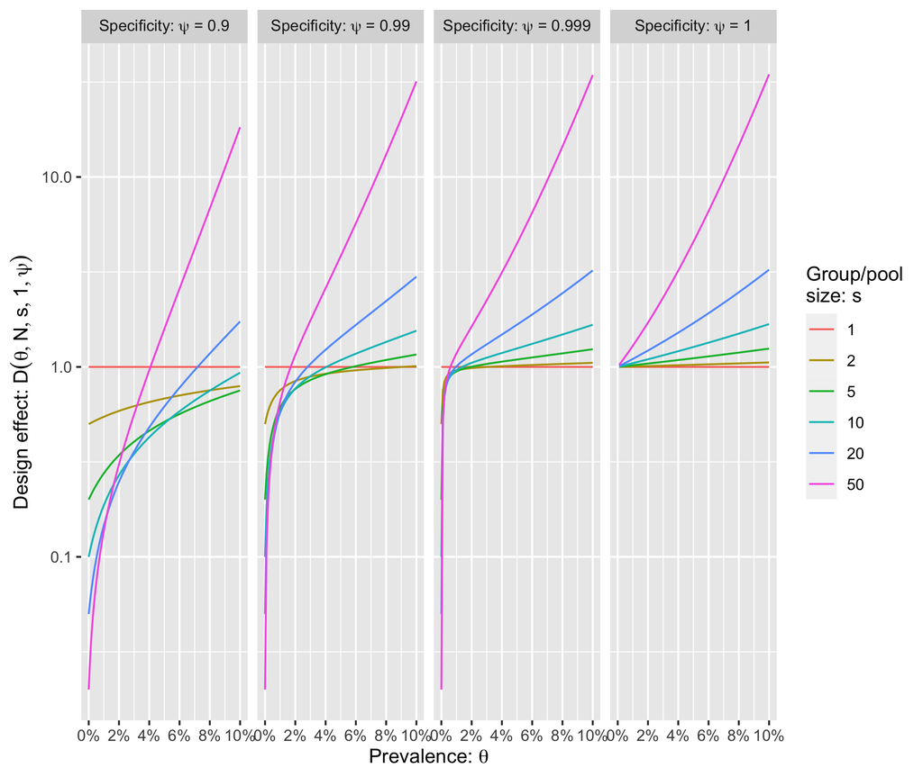

# Design Effect - Imperfect Sensitivity

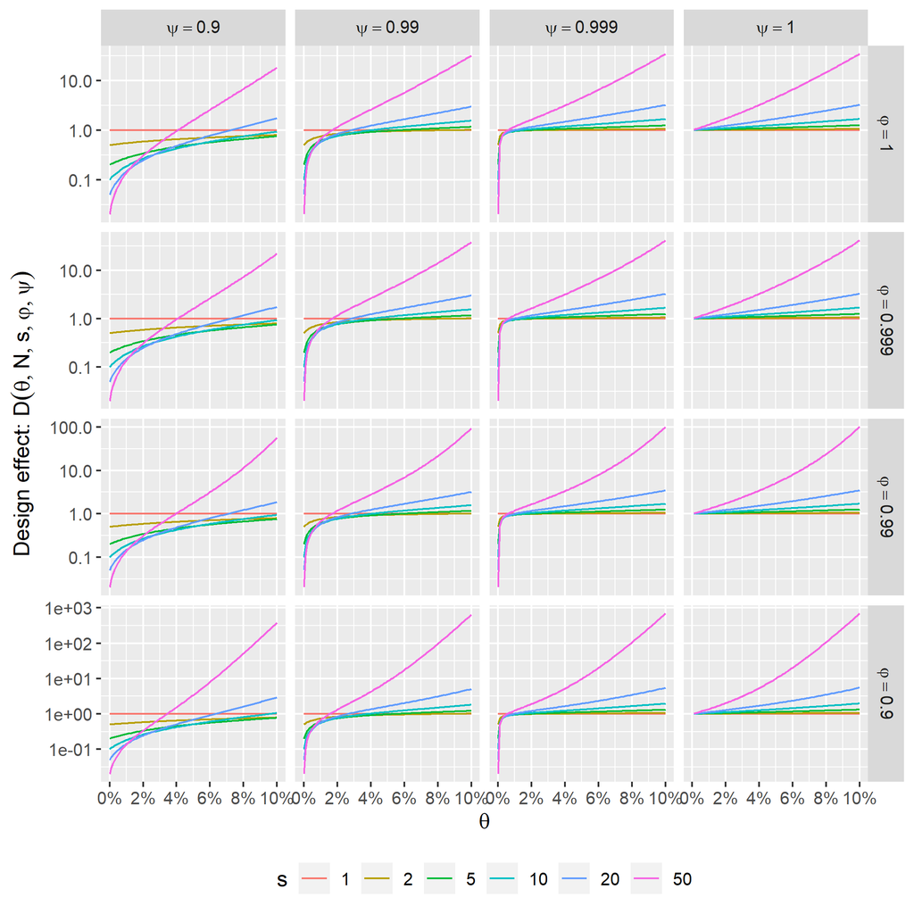

# Optimal Pool Size: Setup

- $c_u$ marginal cost of sampling one unit
- $c_p$ cost of one pool (independent of the number of units in the pool).

# Optimal Pool Size

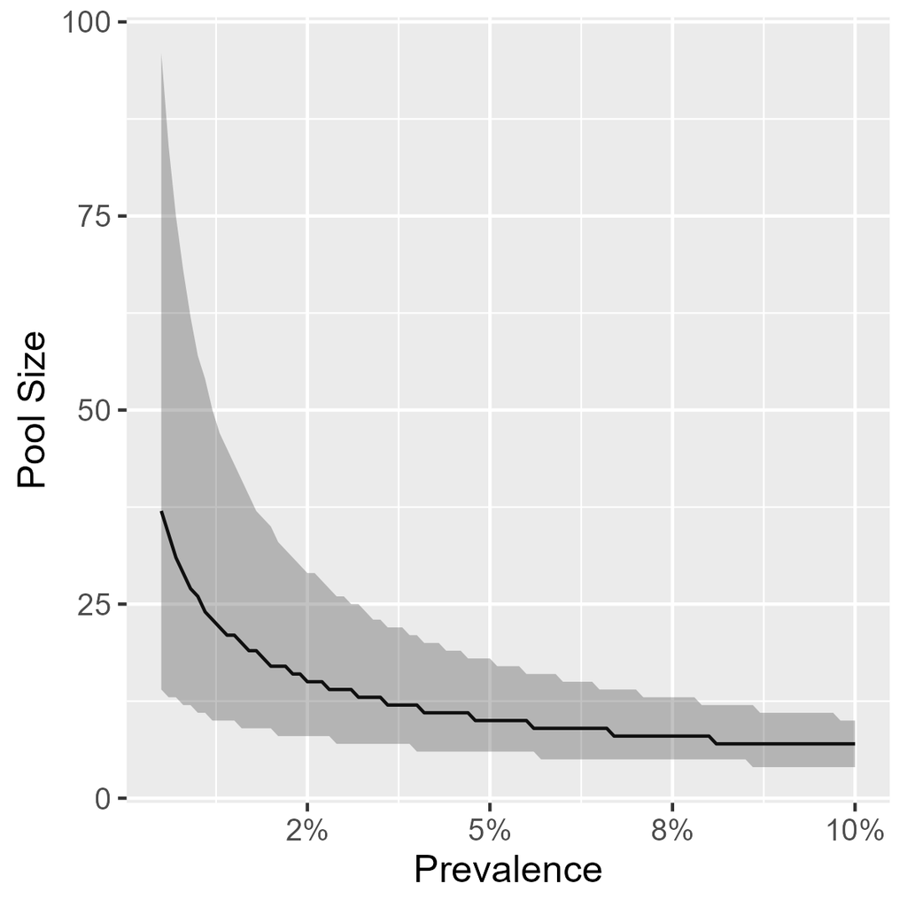

$c_p/c_u = 4$

# Optimal Pool Size

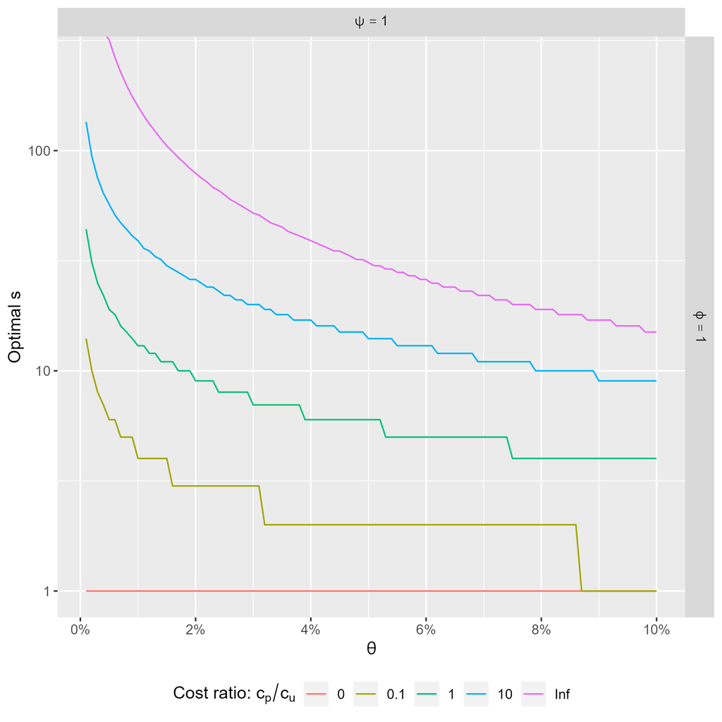

# Optimal Pool Size

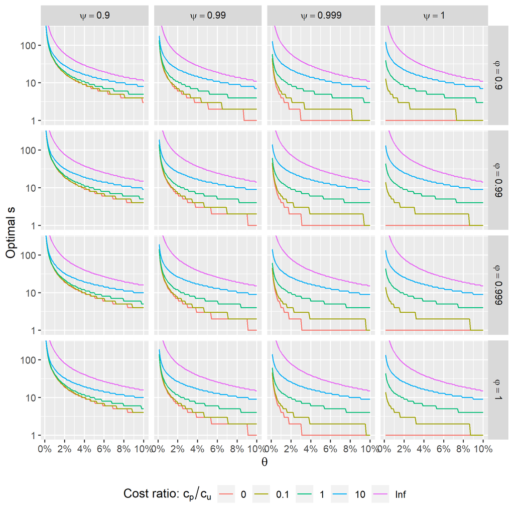

# Cluster surveys

[figure not shown]

# Cluster surveys individual testing

Setup:

- $n$ units are sampled from $J$ location ($n/J$ per location).
- $V_{ij}$ are *correlated* Bernoulli RVs: presence/absence in unit $i$ from location $j$
  $$Corr(V_{ij},V_{i'j'}) = \begin{cases}
  1, & i = i', j = j' \\
  \rho, & i \neq i', j = j' \\
  0, & j \neq j' \\
  \end{cases}$$
  This is *not* a unique description of the correlation structure

# Cluster surveys individual testing

Regardless of higher-order correlation structure, the standard population prevalence estimator
$$\hat{\theta} = \frac{1}{n} \sum_i\sum_j V_{ij}$$
has standard error
$$se(\hat{\theta}) = \sqrt{\dfrac{\hat{\theta}(1-\hat{\theta})D}{n}} =
\sqrt{\dfrac{\hat{\theta}(1-\hat{\theta})}{n_{eff}}}$$
with design effect $D = 1 + \rho (n/J - 1)$ and effective sample size $n_{eff} = n/D$.

Two problems:

- This (standard) approach assumes that $\rho$ is known and only $\theta$ is estimated
- It doesn’t work for pooled tests. :(

# Cluster Survey Pooled Testing

- We have to specify the full correlation structure: joint distribution of $\{V_{ij}\}$
- Model prevalence at each location ($\Theta_j$), with units being independent conditioned on the location:
- $E[\Theta_j] = \theta$ and $f_\Theta(p)$ is density on $[0,1]$.
  $$V_{ij}|\Theta_j \sim Bern(\Theta_j),$$
- This preserves $E[V_{ij}] = \theta$.
- Correlation between two distinct units from the same site, $\rho$, is
  $$\begin{align*}
  \rho := Corr(V_{ij},V_{i'j})
  &= \frac{Var[\Theta_j]}{\theta (1-\theta)}.
  \end{align*}$$

# Cluster Survey Pooled Testing

- Likelihood (and Fisher Information) depends on the first $\underline{s} \cdot \underline{N}$ moments of $\Theta_j$
- specifying $\theta$ and $\rho$ will not be sufficient for $\underline{s} \cdot \underline{N}>2$
- Distributions for $\Theta_j$: e.g. beta, logit-normal.
- The model is not identifiable if $N = 1$. (Fisher Information matrix is not invertible)

# Fisher Information - Beta Distribution

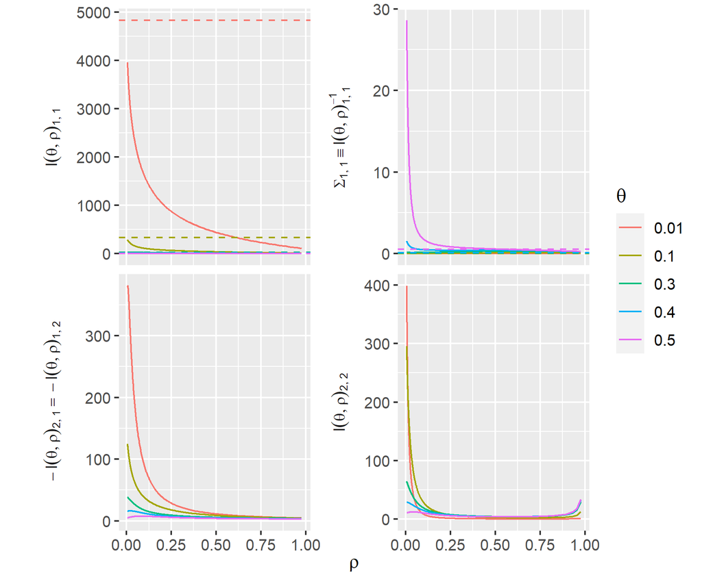

# Fisher Information - Beta Distribution

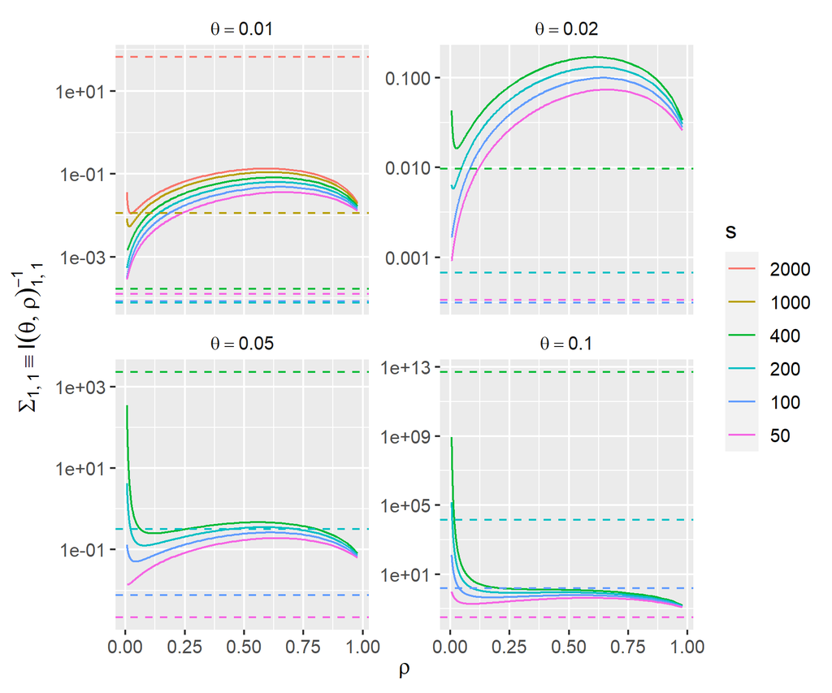

# Unit information - beta

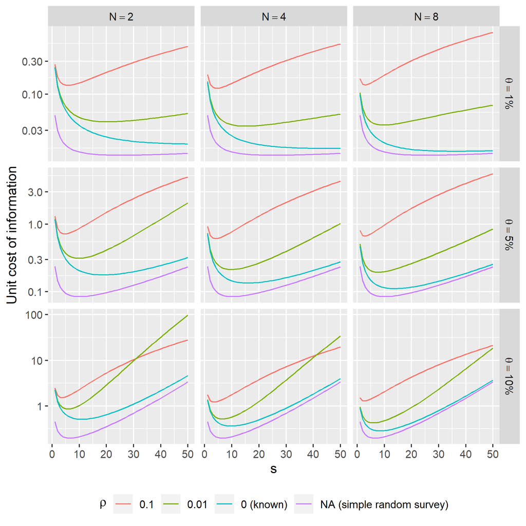

# Unit information - beta

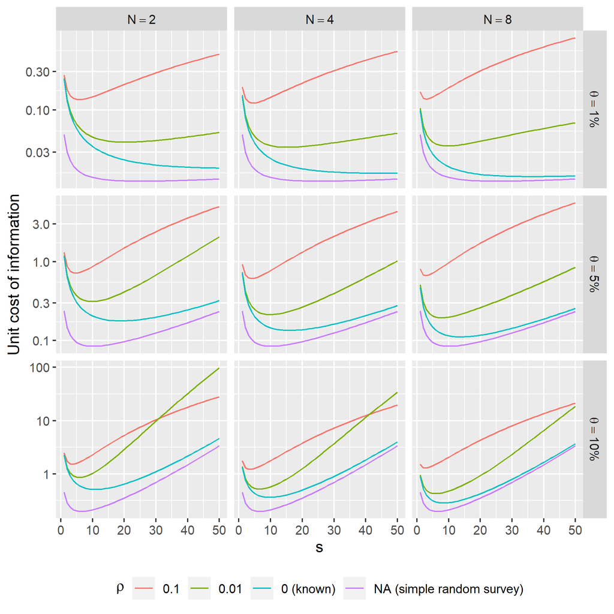

# Optimal cluster

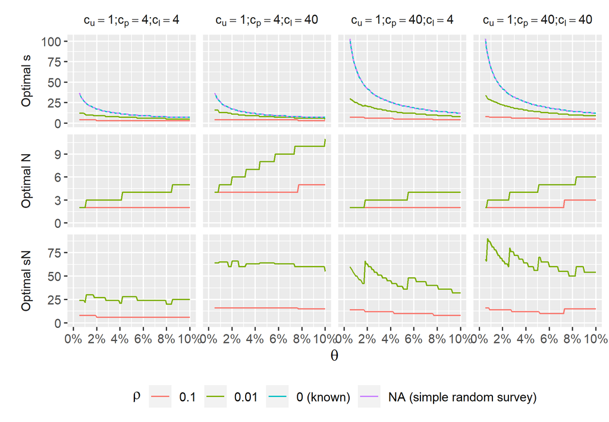